# Project 2: Data Mining, Classification, Prediction

SDS322E

```bash
cd ~
git clone https://github.com/nathanialwoodward/project2.git
```

# Mining, Classification, Prediction

## Arnav Patel (AP53888)

### Introduction

Using the same two data sets set I had in Project 1, I was able to make a similar combined set of data that I named EduElect2. The first data set had 8 variables - region (this includes ENC, East North Central; ESC, East South Central; MA, Mid-Atlantic; MTN, Mountain; NE, New England; PAC, Pacific; SA, South Atlantic; WNC, West North Central; WSC, West South Central), population, average SAT verbal and math scores, percent of high-schoolers who took the SAT, average amount of money spent on public education per student, and the average teacher’s salary in the state. Wondering how these states would be correlated to political party, I made my own data set using data from Harvard’s already existing databases that contained information on what the political party candidate each state voted on during the 1992 presidential election and how many electoral votes those states each had. These data sets interest me because I wanted to see if there was any correlation between spending on public education state by state and the states political affiliations. In order to create a binomial varibale, I mutated the data set to include a varibale called “Party” where if the Political party of the state was Democratic, then it had a value of 1 while if the Political party of the state was Republican, then it had a value of 0. There are a total of 11 variables with 51 observations for each variable (1 for each state and 1 for Washington DC). There are 5 states in the ENC region, 4 states in the ESC region, 3 states in the MA region, 8 states in the MTN region, 6 states in the NE region, 5 states inn the PAC region, 9 states in the SA region, 7 states in the WNC region, and 4 states from the WSC region.

```r
library(tidyverse)
# read your datasets in here, e.g., with read_csv()
library(tidyverse)
library(carData)

# First Dataset (Education and Related Statistics for the
# U.S. States in 1992)
edu <- States
edu <- edu %>% mutate(state = rownames(.))
view(edu)
glimpse(edu)
```

```
## Rows: 51
## Columns: 8
## $ region  <fct> ESC, PAC, MTN, WSC, PAC, MTN, NE, SA, SA, SA, SA, PAC, MTN, E…
## $ pop     <int> 4041, 550, 3665, 2351, 29760, 3294, 3287, 666, 607, 12938, 64…
## $ SATV    <int> 470, 438, 445, 470, 419, 456, 430, 433, 409, 418, 401, 404, 4…
## $ SATM    <int> 514, 476, 497, 511, 484, 513, 471, 470, 441, 466, 443, 481, 5…
## $ percent <int> 8, 42, 25, 6, 45, 28, 74, 58, 68, 44, 57, 52, 17, 16, 54, 5, …
## $ dollars <dbl> 3.648, 7.887, 4.231, 3.334, 4.826, 4.809, 7.914, 6.016, 8.210…
## $ pay     <int> 27, 43, 30, 23, 39, 31, 43, 35, 39, 30, 29, 32, 25, 34, 32, 2…
## $ state   <chr> "AL", "AK", "AZ", "AR", "CA", "CO", "CN", "DE", "DC", "FL", "…
```

```r
# Second Dataset (How many electoral votes and what party was
# voted for in 1992)
Election <- read_csv("Election.csv")
view(Election)
glimpse(Election)
```

```
## Rows: 51
## Columns: 3
## $ state_po        <chr> "AL", "AK", "AZ", "AR", "CA", "CO", "CT", "DE", "DC",…
## $ Party_Voted     <chr> "Republican", "Republican", "Republican", "Democrat",…
## $ Electoral_Votes <dbl> 9, 3, 8, 6, 54, 8, 8, 3, 3, 25, 13, 4, 4, 22, 12, 7, …
```

```r
# your joining code
edu <- edu %>% rename(state_po = state)
edu[7, 8] = "CT"

EduElect <- full_join(edu, Election, by = "state_po")

EduElect2 <- EduElect %>% select(-pop) %>% mutate(Party = ifelse(Party_Voted ==
    "Democrat", "1", "0")) %>% mutate(SAT_Total = SATM + SATV)
view(EduElect2)
glimpse(EduElect2)
```

```
## Rows: 51
## Columns: 11
## $ region          <fct> ESC, PAC, MTN, WSC, PAC, MTN, NE, SA, SA, SA, SA, PAC…
## $ SATV            <int> 470, 438, 445, 470, 419, 456, 430, 433, 409, 418, 401…
## $ SATM            <int> 514, 476, 497, 511, 484, 513, 471, 470, 441, 466, 443…
## $ percent         <int> 8, 42, 25, 6, 45, 28, 74, 58, 68, 44, 57, 52, 17, 16,…
## $ dollars         <dbl> 3.648, 7.887, 4.231, 3.334, 4.826, 4.809, 7.914, 6.01…
## $ pay             <int> 27, 43, 30, 23, 39, 31, 43, 35, 39, 30, 29, 32, 25, 3…
## $ state_po        <chr> "AL", "AK", "AZ", "AR", "CA", "CO", "CT", "DE", "DC",…
## $ Party_Voted     <chr> "Republican", "Republican", "Republican", "Democrat",…
## $ Electoral_Votes <dbl> 9, 3, 8, 6, 54, 8, 8, 3, 3, 25, 13, 4, 4, 22, 12, 7, …
## $ Party           <chr> "0", "0", "0", "1", "1", "1", "1", "1", "1", "0", "1"…
## $ SAT_Total       <int> 984, 914, 942, 981, 903, 969, 901, 903, 850, 884, 844…
```

```r
EduElect2 %>% group_by(region) %>% summarize(n = n())
```

```
## # A tibble: 9 x 2
##   region     n
##   <fct>  <int>
## 1 ENC        5
## 2 ESC        4
## 3 MA         3
## 4 MTN        8
## 5 NE         6
## 6 PAC        5
## 7 SA         9
## 8 WNC        7
## 9 WSC        4
```

### Cluster Analysis

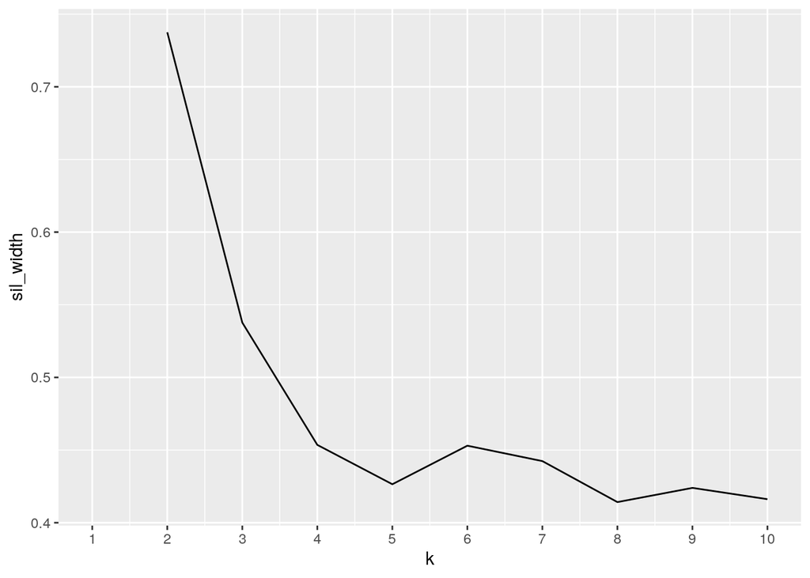

```r
library(cluster)
# clustering code here
clust_dat <- EduElect2 %>% select(percent, dollars, pay)
view(clust_dat)

sil_width <- vector()  #empty vector to hold mean sil width
for (i in 2:10) {
    kms <- kmeans(clust_dat, centers = i)  #compute k-means solution for each k
    sil <- silhouette(kms$cluster, dist(clust_dat))  #get sil widths
    sil_width[i] <- mean(sil[, 3])  #take averages (higher is better)
}
ggplot() + geom_line(aes(x = 1:10, y = sil_width)) + scale_x_continuous(name = "k",
    breaks = 1:10)
```

```r
pam1 <- clust_dat %>% pam(k = 2)  #use the pam function
pam1
```

```
## Medoids:
##      ID percent dollars pay
## [1,] 26      12   4.415  28
## [2,] 47      58   5.360  32
## Clustering vector:
##  [1] 1 2 1 1 2 1 2 2 2 2 2 2 1 1 2 1 1 1 1 2 2 2 1 1 1 1 1 1 1 2 2 1 2 2 1 1 1 2
## [39] 2 2 2 1 1 2 1 2 2 2 1 1 1
## Objective function:
##    build     swap
## 11.53366  7.84517
##
## Available components:
##  [1] "medoids"    "id.med"     "clustering" "objective"  "isolation"
##  [6] "clusinfo"   "silinfo"    "diss"       "call"       "data"
```

```r
pam1$silinfo$avg.width
```

```
## [1] 0.7375236
```

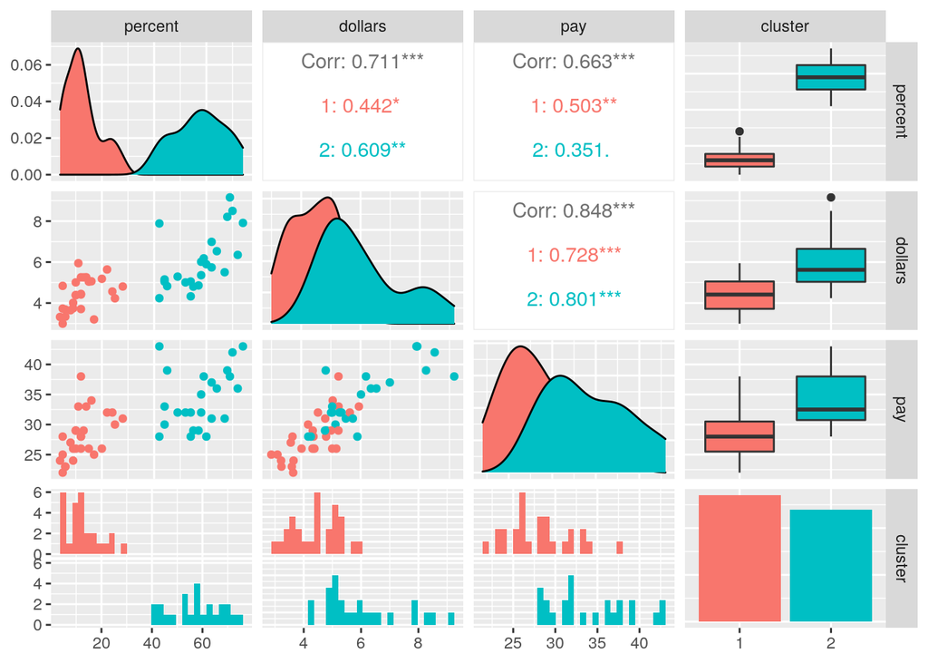

```r
pamclust <- clust_dat %>% mutate(cluster = as.factor(pam1$clustering))

library(GGally)
ggpairs(pamclust, columns = 1:4, aes(color = cluster))
```

For the Cluster Analysis, I used the variables of percent, dollars, and pay because I believe that in order to see how important education spending is in each state, these three numerical variables would be most useful. Using a silhuete width graph, I was able to see that the highest value sil_width was when k = 2 which is why I used a value of k = 2. Looking at the cluster analysis, it is clear that the blue cluster has higher values for percent, dollars, and pay compared to the red cluster meaning the blue cluster has all the states that spend more on education and also have more students taking the SAT. The average silhouette width when there are 2 clusters is ~0.74 which means this is really good as it is close to a value of 1.

### Dimensionality Reduction with PCA

```r
# PCA code here
PCA_dat <- EduElect2 %>% select(percent, dollars, pay)

PCA <- princomp(PCA_dat, cor = T)

summary(PCA, loadings = "T")
```

```
## Importance of components:
##                           Comp.1    Comp.2     Comp.3
## Standard deviation     1.5760953 0.6062278 0.38524217
## Proportion of Variance 0.8280255 0.1225040 0.04947051
## Cumulative Proportion  0.8280255 0.9505295 1.00000000
##
## Loadings:
##         Comp.1 Comp.2 Comp.3
## percent  0.548  0.829  0.114
## dollars  0.597 -0.292 -0.747
## pay      0.586 -0.477  0.655
```

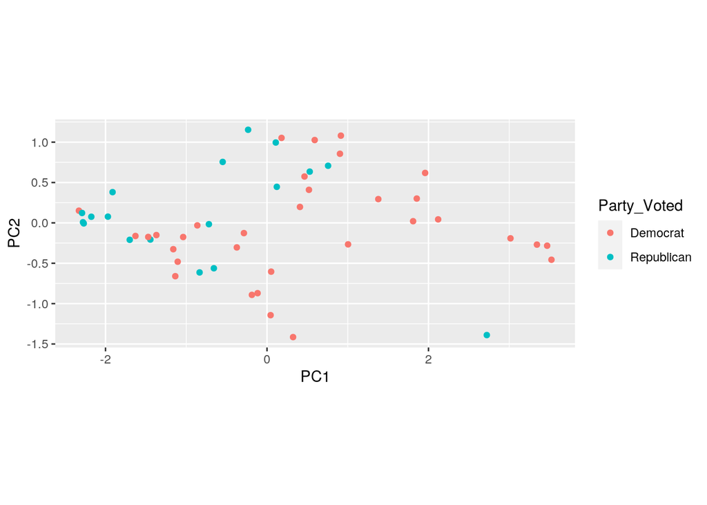

```r
EduElect2 %>% mutate(PC1 = PCA$scores[, 1], PC2 = PCA$scores[,
    2]) %>% ggplot(aes(PC1, PC2, color = Party_Voted)) + geom_point() +
    coord_fixed()
```

```r
# linear classifier code here
EduElect2$Party <- as.numeric(EduElect2$Party)
log_fit <- glm(Party ~ SAT_Total + percent + dollars + pay +
    Electoral_Votes, data = EduElect2, family = "binomial")
pred_prob <- predict(log_fit, type = "response")
class_diag(pred_prob, EduElect2$Party, positive = "1")
```

```
##            acc   sens   spec    ppv     f1    ba    auc
## Metrics 0.7451 0.8485 0.5556 0.7778 0.8116 0.702 0.8064
```

```r
# cross-validation of linear classifier here
set.seed(1234)
k = 10  #choose number of folds
data <- sample_frac(EduElect2)
folds <- rep(1:k, length.out = nrow(data))  #create folds
diags <- NULL
for (i in 1:k) {
    ## Create training and test sets
    train <- data[folds != i, ]
    test <- data[folds == i, ]
    truth <- test$Party  ## Truth labels for fold i
    ## Train model on training set (all but fold i)
    fit <- glm(Party ~ SAT_Total + percent + dollars + pay +
        Electoral_Votes, data = EduElect2, family = "binomial")
    ## Test model on test set (fold i)
    probs <- predict(fit, newdata = test, type = "response")
    ## Get diagnostics for fold i
    diags <- rbind(diags, class_diag(probs, truth, positive = 1))
}
summarize_all(diags, mean)  #average diagnostics across all k folds
```

```
##       acc    sens spec   ppv      f1      ba     auc
## 1 0.74667 0.83334  0.6 0.775 0.79594 0.71667 0.81945
```

After using a logistic regression, using the numerical variables and the variable of Party (1 for Democrat, 0 for Republican), I calculated a AUC of 0.8064. After using cross validation with 10 folds, the AUC increased very very slightly to 0.81945 which may indicate a low level of overfitting from the logistic regression model.

### Non-Parametric Classifier

```r
library(caret)
# non-parametric classifier code here
knn_fit <- knn3(Party ~ SAT_Total + percent + dollars + pay +
    Electoral_Votes, data = EduElect2)
y_hat_knn <- predict(knn_fit, EduElect2)
y_hat_knn
```

```
##         0   1
##  [1,] 0.4 0.6
##  [2,] 0.2 0.8
##  [3,] 0.2 0.8
##  [4,] 0.4 0.6
##  [5,] 0.4 0.6
##  [6,] 0.4 0.6
##  [7,] 0.0 1.0
##  [8,] 0.2 0.8
##  [9,] 0.6 0.4
## [10,] 0.6 0.4
## [11,] 0.6 0.4
## [12,] 0.2 0.8
## [13,] 0.6 0.4
## [14,] 0.0 1.0
```

[output cut: 37 more lines]

```r
class_diag(y_hat_knn[, 2], EduElect2$Party, positive = "1")
```

```
##            acc   sens   spec    ppv     f1     ba   auc
## Metrics 0.7843 0.8788 0.6111 0.8056 0.8406 0.7449 0.782
```

```r
# cross-validation of np classifier here
set.seed(1234)
k = 10  #choose number of folds
data <- sample_frac(EduElect2)
folds <- rep(1:k, length.out = nrow(data))  #create folds
diags <- NULL
i = 1
for (i in 1:k) {
    ## Create training and test sets
    train <- data[folds != i, ]
    test <- data[folds == i, ]
    truth <- test$Party  ## Truth labels for fold i
    ## Train model on training set (all but fold i)
    fit <- knn3(Party ~ SAT_Total + percent + dollars + pay +
        Electoral_Votes, data = EduElect2)
    ## Test model on test set (fold i)
    probs <- predict(fit, newdata = test)[, 2]
    ## Get diagnostics for fold i
    diags <- rbind(diags, class_diag(probs, truth, positive = 1))
}
summarize_all(diags, mean)  #average diagnostics across all k folds
```

```
##       acc    sens    spec     ppv      f1      ba     auc
## 1 0.78333 0.87501 0.58333 0.82667 0.83397 0.72916 0.76666
```

Discussion

After using a KNN Model, using the numerical variables and the variable of Party (1 for Democrat, 0 for Republican), I calculated a AUC of 0.782 which shows that the model is pretty well designed. After using cross validation with 10 folds, the AUC decrease slightly to 0.76666 which indicates that the original KNN model did better than the cross validation model meaning the CV might have lowkey overfit. Furthermore, compared to the linear model, because the KNN model had a lower AUC, we assume the linear model was a better fit for the data.

### Regression/Numeric Prediction

```r
# regression model code here
Reg_Fit <- lm(SAT_Total ~ percent + dollars + pay + Party, data = EduElect2)
Predict <- predict(Reg_Fit)
mean((EduElect2$SAT_Total - Predict)^2)
```

```
## [1] 881.3809
```

```r
# cross-validation of regression model here
set.seed(1234)
k = 5  #choose number of folds
data <- EduElect2[sample(nrow(EduElect2)), ]  #randomly order rows
folds <- cut(seq(1:nrow(EduElect2)), breaks = k, labels = F)  #create folds
diags <- NULL
for (i in 1:k) {
    train <- data[folds != i, ]
    test <- data[folds == i, ]
    ## Fit linear regression model to training set
    fit <- lm(SAT_Total ~ percent + dollars + pay + Party, data = EduElect2)
    ## Get predictions/y-hats on test set (fold i)
    yhat <- predict(fit, newdata = test)
    ## Compute prediction error (MSE) for fold i
    diags <- mean((test$SAT_Total - yhat)^2)
}
mean(diags)  ## get average MSE across all folds!
```

```
## [1] 688.243
```

### Python

```r
library(reticulate)
use_python("/usr/bin/python3", required = F)
message <- "Hello Professor Woodward"
cat(c(message, py$message))
```

```
## Hello Professor Woodward
```

```python
# python code here
message="and TA Yiwei."
print(r.message, message)
```

```
## Hello Professor Woodward and TA Yiwei.
```

### Concluding Remarks

No conluding remarks!